# **Analysis of Major NBA Scoring Statistics in the 2022-23 Season**

**CMSC320 Final Project**

Contribution:

Member 1: Shreyas Ramulu, Contribution: 100%

Member 2: Shuaib Syed, Contribution: 100%

Member 3: Madhav Murikipudi, Contribution: 100%

"We, all team members, agree together that the above information is true, and we are confident about our contributions to this submitted project/final tutorial."

- Madhav Murikipudi (05/05/2024)
- Shreyas Ramulu (05/05/2024)
- Shuaib Syed (05/05/2024)

Contribution Summary:

- Shreyas: We each came up with the idea part of the project together through FaceTime. For the dataset curation and preprocessing, we again did this part over FaceTime, deciding which columns to keep and cleaning the data together. For this part, we each did one of the hypothesis analyses questions. For this part, I did the "How Does Position Affect the 3 Major Player Statistics?" question. Again, for the ML algorithm development, we did this process together by FaceTiming and brainstorming which method of ML we should use and how to do it. In the end, we decided on regression using Random Forest Regression. We also did the ML training and testing together over FaceTime. For the visualization part of this process, we each took one type of visualization to do. For this step, I did the decision tree graph. Finally, we did the conclusion and uploading the webpage on Git together over FaceTime as well.
- Shuaib: We each came up with the idea part of the project together through FaceTime. For the dataset curation and preprocessing, we again did this part over FaceTime, deciding which columns to keep and cleaning the data together. For this part, we each did one of the hypothesis analyses questions. For this part, I did the "How Does Team Strength Affect the 3 Major Player Statistics?" question. Again, for the ML algorithm development, we did this process together by FaceTiming and brainstorming which method of ML we should use and how to do it. In the end, we decided on regression using Random Forest Regression. We also did the ML training and testing together over FaceTime. For the visualization part of this process, we each took one type of visualization to do. For this step, I did the feature importance graph. Finally, we did the conclusion and uploading the webpage on Git together over FaceTime as well.
- Madhav: We each came up with the idea part of the project together through FaceTime. For the dataset curation and preprocessing, we again did this part over FaceTime, deciding which columns to keep and cleaning the data together. For this part, we each did one of the hypothesis analyses questions. For this part, I did the "How Does Age Affect the 3 Major Player Statistics?" question. Again, for the ML algorithm development, we did this process together by FaceTiming and brainstorming which method of ML we should use and how to do it. In the end, we decided on regression using Random Forest Regression. We also did the ML training and testing together over FaceTime. For the visualization part of this process, we each took one type of visualization to do. For this step, I did the regression of R^2 graph. Finally, we did the conclusion and uploading the webpage on Git together over FaceTime as well.

# **1. Introduction**

In the fast paced world of basketball, the performance of the players is often refined into quantifiable data, which then is scrutinized by teams and fans alike. This data is used to determine the skills and worth of a NBA player and team either to get players or learn more about the strenghts and weakensses of a team. This project takes a look at the player statistics from the 2022/2023 NBA regular season. We are focusing on the main three statistics: points, rebounds, and assists.

By looking at these statistics, this project aims to uncover some patterns and insights that can contribute to a deeper understanding of player performance and possibly even team success. Through the comprehensive data science pipeline of data collection, processing, exploratory analysis, and visualization, we look to provide that deeper understanding of player performance. Additionally this project uses modeling techniques to test some hypotheses and apply machine learning algorithms as well, aiming to predict points, assists, and rebounds of NBA players.

# **2. Data Curation**

Source of Data: https://www.kaggle.com/datasets/vivovinco/20222023-nba-player-stats-regular

This is the website where we acquired our data about the NBA. This data has all the player's game statistics in the NBA during the regular season. Some of the main statistics include

- Player position
- Player Team
- Player Age
- Player Points Per Game
- Player Assists Per Game
- Player Rebounds Per Game

Imports:

```python
import pandas as pd
import numpy as np
import math
from datetime import datetime
import matplotlib.pyplot as plt
from scipy import stats
from scipy.stats import f_oneway
from sklearn.ensemble import RandomForestRegressor
from sklearn.model_selection import train_test_split
from sklearn.metrics import mean_squared_error
from sklearn.tree import plot_tree
```

Set Up Our Dataframe:

```python
df = pd.read_csv("RegularNBAStats.csv", encoding='latin1', sep = ';')
df
```

|  | Rk | Player | Pos | Age | Tm | G | GS | MP | FG | FGA | ... | FT% | ORB | DRB | TRB | AST | STL | BLK | TOV | PF | PTS |
| --- | --- | --- | --- | --- | --- | --- | --- | --- | --- | --- | --- | --- | --- | --- | --- | --- | --- | --- | --- | --- | --- |
| 0 | 1 | Precious Achiuwa | C | 23 | TOR | 55 | 12 | 20.7 | 3.6 | 7.3 | ... | 0.702 | 1.8 | 4.1 | 6.0 | 0.9 | 0.6 | 0.5 | 1.1 | 1.9 | 9.2 |
| 1 | 2 | Steven Adams | C | 29 | MEM | 42 | 42 | 27.0 | 3.7 | 6.3 | ... | 0.364 | 5.1 | 6.5 | 11.5 | 2.3 | 0.9 | 1.1 | 1.9 | 2.3 | 8.6 |
| 2 | 3 | Bam Adebayo | C | 25 | MIA | 75 | 75 | 34.6 | 8.0 | 14.9 | ... | 0.806 | 2.5 | 6.7 | 9.2 | 3.2 | 1.2 | 0.8 | 2.5 | 2.8 | 20.4 |
| 3 | 4 | Ochai Agbaji | SG | 22 | UTA | 59 | 22 | 20.5 | 2.8 | 6.5 | ... | 0.812 | 0.7 | 1.3 | 2.1 | 1.1 | 0.3 | 0.3 | 0.7 | 1.7 | 7.9 |
| 4 | 5 | Santi Aldama | PF | 22 | MEM | 77 | 20 | 21.8 | 3.2 | 6.8 | ... | 0.750 | 1.1 | 3.7 | 4.8 | 1.3 | 0.6 | 0.6 | 0.8 | 1.9 | 9.0 |
| ... | ... | ... | ... | ... | ... | ... | ... | ... | ... | ... | ... | ... | ... | ... | ... | ... | ... | ... | ... | ... | ... |
| 674 | 535 | Thaddeus Young | PF | 34 | TOR | 54 | 9 | 14.7 | 2.0 | 3.7 | ... | 0.692 | 1.3 | 1.8 | 3.1 | 1.4 | 1.0 | 0.1 | 0.8 | 1.6 | 4.4 |
| 675 | 536 | Trae Young | PG | 24 | ATL | 73 | 73 | 34.8 | 8.2 | 19.0 | ... | 0.886 | 0.8 | 2.2 | 3.0 | 10.2 | 1.1 | 0.1 | 4.1 | 1.4 | 26.2 |
| 676 | 537 | Omer Yurtseven | C | 24 | MIA | 9 | 0 | 9.2 | 1.8 | 3.0 | ... | 0.833 | 0.9 | 1.7 | 2.6 | 0.2 | 0.2 | 0.2 | 0.4 | 1.8 | 4.4 |
| 677 | 538 | Cody Zeller | C | 30 | MIA | 15 | 2 | 14.5 | 2.5 | 3.9 | ... | 0.686 | 1.7 | 2.6 | 4.3 | 0.7 | 0.2 | 0.3 | 0.9 | 2.2 | 6.5 |
| 678 | 539 | Ivica Zubac | C | 25 | LAC | 76 | 76 | 28.6 | 4.3 | 6.8 | ... | 0.697 | 3.1 | 6.8 | 9.9 | 1.0 | 0.4 | 1.3 | 1.5 | 2.9 | 10.8 |

679 rows × 30 columns

# **3. Exploratory Data Analysis**

Now that we have set up our data frame lets clean it and learn more about the data.

## Data Cleaning And Data Characteristics

Look at characteristics of Data Frame and see if we need to modify anything

Below are the features in our dataframe, and their respective types. Looking at the types of our data they are in the correct format. All our percentages are floats and none of them are over 100%.

```python
# Analyze the data types of each column
print(df.dtypes)
```

```
Rk          int64
Player     object
Pos        object
Age         int64
Tm         object
G           int64
GS          int64
MP        float64
FG        float64
FGA       float64
FG%       float64
3P        float64
3PA       float64
3P%       float64
2P        float64
2PA       float64
2P%       float64
eFG%      float64
FT        float64
FTA       float64
FT%       float64
ORB       float64
DRB       float64
TRB       float64
AST       float64
STL       float64
BLK       float64
TOV       float64
PF        float64
PTS       float64
dtype: object
```

Lets check that we don't have any missing data points in our data frame.

Below we can see none of rows have missing data and all the columns have 679 rows. So we do not have to remove any records

```python
print("Number of rows:",df.shape[0])
print()
df.count()
```

```
Number of rows: 679
```

```
Rk        679
Player    679
Pos       679
Age       679
Tm        679
G         679
GS        679
MP        679
FG        679
FGA       679
FG%       679
3P        679
3PA       679
3P%       679
2P        679
2PA       679
2P%       679
eFG%      679
FT        679
FTA       679
FT%       679
ORB       679
DRB       679
TRB       679
AST       679
STL       679
BLK       679
TOV       679
PF        679
PTS       679
dtype: int64
```

Let's also look at the statistics of of our columns. We have alot of columns so we will look at the most important columns that have numerical values

- Age
- Points
- Total Rebounds
- Assists
- Steals
- Blocks

We chose to look at the statistics of these columns beacause they are the best at describing play style of a player

```python
selected_columns = ['Age', 'PTS', 'TRB', 'AST', 'STL', 'BLK']
df[selected_columns].describe()
```

|  | Age | PTS | TRB | AST | STL | BLK |
| --- | --- | --- | --- | --- | --- | --- |
| count | 679.000000 | 679.000000 | 679.000000 | 679.000000 | 679.000000 | 679.000000 |
| mean | 26.025037 | 8.858763 | 3.461414 | 2.011635 | 0.601767 | 0.370398 |
| std | 4.325709 | 6.631226 | 2.281317 | 1.891472 | 0.392063 | 0.367514 |
| min | 19.000000 | 0.000000 | 0.000000 | 0.000000 | 0.000000 | 0.000000 |
| 25% | 23.000000 | 4.100000 | 1.800000 | 0.800000 | 0.300000 | 0.100000 |
| 50% | 25.000000 | 6.900000 | 3.000000 | 1.300000 | 0.500000 | 0.300000 |
| 75% | 29.000000 | 11.550000 | 4.500000 | 2.700000 | 0.800000 | 0.500000 |
| max | 42.000000 | 33.100000 | 12.500000 | 10.700000 | 3.000000 | 3.000000 |

## Now we are going to delve deeper into our dataset

## **Question 1: How Does Age Affect the 3 Major Player Statistics?**

We want to answer how age affects PPG, APG, RPG. To test this we will make a scatterplot with these three catagories and we will find a line of best fit for each graph. Lastly we will find the Pearson's Correlation between the three scatter plots.

First we are creating a box plot of age to see how it is distributed. We want to make sure there aren't too many outliers in age.

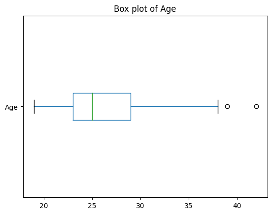

```python
df.boxplot(column='Age', vert = False, grid = False)
plt.title('Box plot of Age')
plt.show()
```

We see that the there aren't to many outliers so we can continue to create a scatter plot.We have no need to remove any outliers or adjust our data.

For our Statistical Test we will find a **line of best fit** for each catagory and find the **Pearson correlation** to see how strong the correlation is.

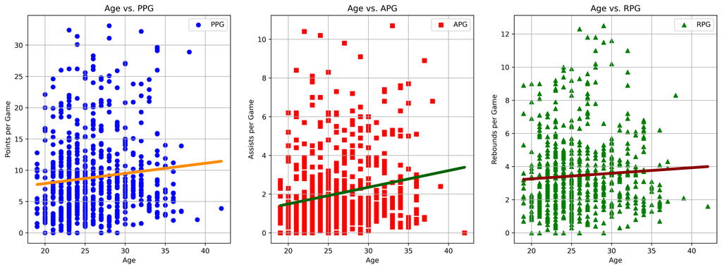

```python
# Create easier variables to work with
age = df['Age']
ppg = df['PTS']
apg = df['AST']
rpg = df['TRB']

# Create separate subplots for each variable
# The graph were pixelated so incresed dpi and make the graphs appear next to eachother
fig, (ppgGraph, apgGraph, rpgGraph) = plt.subplots(1, 3, figsize=(18, 6), dpi = 500)

# Plot for PPG
ppgGraph.scatter(age, ppg, label='PPG', color='blue', marker='o')
# Make a line of best fit of 1 degree (Not repeating comments for sections later)
m, b = np.polyfit(age, ppg, 1)
# Plot the line also make it contrasting color and thicker to show up on graph
ppgGraph.plot(age, m * age + b, color='darkorange', linewidth=4)
ppgGraph.set_title('Age vs. PPG')
ppgGraph.set_xlabel('Age')
ppgGraph.set_ylabel('Points per Game')
ppgGraph.legend()
ppgGraph.grid(True)

# Plot for APG
apgGraph.scatter(age, apg, label='APG', color='red', marker='s')
m, b = np.polyfit(age, apg, 1)
apgGraph.plot(age, m * age + b, color='darkgreen', linewidth=4)
apgGraph.set_title('Age vs. APG')
apgGraph.set_xlabel('Age')
apgGraph.set_ylabel('Assists per Game')
apgGraph.legend()
apgGraph.grid(True)

# Plot for RPG
rpgGraph.scatter(age, rpg, label='RPG', color='green', marker='^')
m, b = np.polyfit(age, rpg, 1)
rpgGraph.plot(age, m * age + b, color='darkred', linewidth=4)
rpgGraph.set_title('Age vs. RPG')
rpgGraph.set_xlabel('Age')
rpgGraph.set_ylabel('Rebounds per Game')
rpgGraph.legend()
rpgGraph.grid(True)

plt.show()
```

From these scatter plots we can see that the correlations aren't that strong but lets see the pearson's correlation between the catagories.

```python
correlation_matrix = np.corrcoef([age, ppg, apg, rpg])

print("Correlation coefficients:")
print("PPG vs. Age:", correlation_matrix[1, 0])
print("APG vs. Age:", correlation_matrix[2, 0])
print("RPG vs. Age:", correlation_matrix[3, 0])
```

```
Correlation coefficients:
PPG vs. Age: 0.10534620451126445
APG vs. Age: 0.19677840184705428
RPG vs. Age: 0.06390285239870638
```

**CONCLUSION:**

From the graph, we see that there isn't a strong relation between age and the three other categories. We can also see that the correlations between age and the 3 major statistics aren’t strong as well. Due to these weak correlations, it would be best to focus on other features, as they clearly will not give us valuable insight in predicting PPG, RPG, and APG.

## **Question 2: How Does Position Affect the 3 Major Player Statistics?**

We want to answer how position affects PPG, APG, RPG. We first create a bar graph to look at our data, visually. We then will run ANOVA tests to statistically analyze the effects position has on the three major player statistics.

```python
# Check distribution of positions
df['Pos'].value_counts()
```

```
Pos
SG       168
PG       135
C        129
SF       125
PF       117
PF-SF      3
SF-SG      1
SG-PG      1
Name: count, dtype: int64
```

As we can see the position column is very cluttered with many extraneous positions. So we simplified the catagories to Guards, Forwards, and Center.

```python
# We merge positions so that there are only centers, forwards, and guards
# If a player is SF-SG, we consider them a forward, as they would need the play-style of a forward to do this
df['Pos'] = df['Pos'].replace({
    'PG': 'G',
    'SG': 'G',
    'PG-SG': 'G',
    'SG-PG': 'G',
    'G': 'G',    # Including this in case 'G' is already a category
    'SF-SG': 'F',
    'SF': 'F',
    'PF': 'F',
    'SF-PF': 'F',
    'PF-SF': 'F',
    'F': 'F',  # Including this in case 'F' is already a category
    # Assuming 'C' is already used for centers and doesn't need to be replaced
})

# Check distributions once again
df['Pos'].value_counts()
```

```
Pos
G    304
F    246
C    129
Name: count, dtype: int64
```

We first create a bar graph to visualize the differences among the 3 major scoring categories across different position groups. This allows us to vizualize data and see how the average of stats compare between positions.

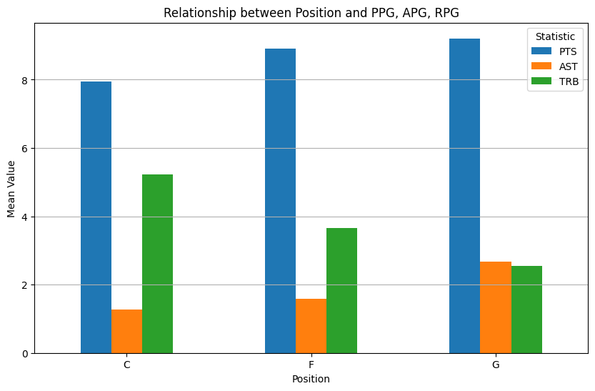

```python
# Bar Graph To Show Relationship Between Postion And PPG, APG, RPG
position_stats = df.groupby('Pos')[['PTS', 'AST', 'TRB']].mean()

# Plotting the bar graph
position_stats.plot(kind='bar', figsize=(10, 6))
plt.title('Relationship between Position and PPG, APG, RPG')
plt.xlabel('Position')
plt.ylabel('Mean Value')
plt.xticks(rotation=0)  # Makes the labels verticle
plt.legend(title='Statistic')
plt.grid(axis='y')

plt.show()
```

We can see minor differences across these groups, with centers having most notably the fewest points and most rebounds, while the guards have the most points and assists and fewest rebounds.

We next run ANOVA tests, to see if there are position has a significant effect on PPG, APG, and RPG. ANOVA tests are most appropriate in this scenario, as we are comparing the mean of over 2 (3) groups.

Null Hypothesis 1: Position does not affect PPG. Alternate Hypothesis 1: Postion affects PPG.

Null Hypothesis 2: Position does not affect APG. Alternate Hypothesis 2: Postion affects APG.

Null Hypothesis 3: Position does not affect RPG. Alternate Hypothesis 3: Postion affects RPG.

Significance Level: 0.05

```python
# We next run an ANOVA test
anova_pos_apg = f_oneway(df['AST'][df['Pos'] == 'C'], df['AST'][df['Pos'] == 'F'], df['AST'][df['Pos'] == 'G'])
anova_pos_rpg = f_oneway(df['TRB'][df['Pos'] == 'C'], df['TRB'][df['Pos'] == 'F'], df['TRB'][df['Pos'] == 'G'])
anova_pos_ppg = f_oneway(df['PTS'][df['Pos'] == 'C'], df['PTS'][df['Pos'] == 'F'], df['PTS'][df['Pos'] == 'G'])

# Printing the results
print("ANOVA results for Position vs APG:")
print("P-value:", anova_pos_apg.pvalue)
print()
print("ANOVA results for Postion vs RPG:")
print("P-value:", anova_pos_rpg.pvalue)
print()
print("ANOVA results for Position vs PPG:")
print("P-value:", anova_pos_ppg.pvalue)
```

```
ANOVA results for Position vs APG:
P-value: 9.40396245444161e-17

ANOVA results for Postion vs RPG:
P-value: 4.284116988772909e-31

ANOVA results for Position vs PPG:
P-value: 0.1910406413523737
```

So we see a significant difference between one of the positions and APG

We also see a significant difference between one of the positions and RPG

**CONCLUSION:**

While our graph does not show major differences between PPG, APG, and RPG among different positions, we run ANOVA tests to further analyze these differences. Through these tests, we learn that position does have an effect on player RPG and APG. This could be the case, as it positively impacts how easy it is to get rebounds. Being closer to the backboard is an extremely large advantage when rebounding, and centers and forwards are generally taller.

A post hoc test with our 2 tests that gave us a significant value could also be worthwhile to find which positions differed from which.

## **Question 3: How Does Team Strength Affect the 3 Major Player Statistics?**

We want to answer how team affects PPG, APG, RPG. We will sort teams into two groups: playoff teams and non-playoff teams. We will then look to see if PPG, RPG, and APG varies across these two groups. We will first create a bar chart to visualize the statistics among these two groups. We will then conduct t-tests to statistically analyze the differences (or lack of differences) among playoff and non-playoff teams.

Our first step is to create our two groups: playoff and non-playoff teams.

```python
# We first check to see the distribution of teams
df['Tm'].value_counts()
```

```
Tm
TOT    70
BRK    25
POR    24
LAL    24
WAS    23
DAL    23
UTA    23
SAS    23
DET    22
LAC    21
MIL    21
PHI    21
SAC    20
TOR    20
PHO    20
IND    20
ORL    20
MIN    20
MIA    20
ATL    20
MEM    19
CHO    19
OKC    19
BOS    18
DEN    18
GSW    18
CHI    18
CLE    18
HOU    18
NYK    17
NOP    17
Name: count, dtype: int64
```

```python
# We assign a new variable 0 if the player was on a playoff team, and 1 if on a non-playoff team
# We choose to count the top 8 seeds from each conferences as a playoff team. Play-in teams are excluded from
# the playoff category as they are not "full" playoff teams, and this would overcrowd the category

# Create list of playoff teams
playoff_teams = ['MIL', 'BOS', 'PHI', 'CLE', 'NYK', 'BRK', 'MIA', 'ATL', 'DEN', 'MEM', 'SAC', 'PHO', 'LAC', 'GSW', 'LAL', 'MIN']

# Create new variable
df['Playoff'] = df['Tm'].apply(lambda x: 0 if x in playoff_teams else 1)

# Check to make sure grouping worked and that distribution is alright
grouped = df['Playoff'].value_counts()
print("Below is the distribution of playoff (0) and non-playoff (1) team players:")
print(grouped)
grouped_teams = df.groupby('Playoff')['Tm'].apply(list)
print("Below is the distribution of playoff (0) and non-playoff (1) teams:")
print(grouped_teams)
```

```
Below is the distribution of playoff (0) and non-playoff (1) team players:
Playoff
1    359
0    320
Name: count, dtype: int64
Below is the distribution of playoff (0) and non-playoff (1) teams:
Playoff
0    [MEM, MIA, MEM, MIN, MIL, CLE, MIN, MIL, MIL, ...
1    [TOR, UTA, TOT, UTA, NOP, ORL, TOR, TOT, POR, ...
Name: Tm, dtype: object
```

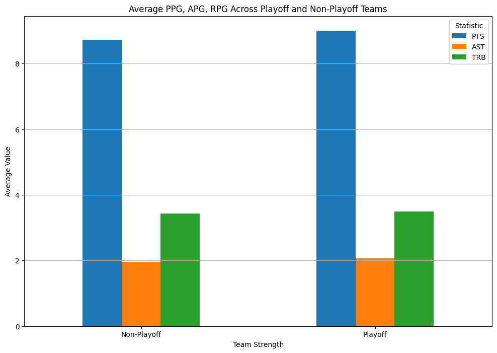

```python
# Create a string version of Playoff variable
df['Playof_str'] = df['Playoff'].replace({0: 'Playoff', 1: 'Non-Playoff'})

# Grouping data by 'Team_Strength' and calculating mean values
team_stats = df.groupby('Playof_str')[['PTS', 'AST', 'TRB']].mean()

# Plotting the bar graph
team_stats.plot(kind='bar', figsize=(12, 8), rot=0)  # rot=0 makes the labels horizontal
plt.title('Average PPG, APG, RPG Across Playoff and Non-Playoff Teams')
plt.xlabel('Team Strength')
plt.ylabel('Average Value')
plt.xticks(rotation='horizontal')  # Ensures labels are horizontal
plt.legend(title='Statistic')
plt.grid(axis='y')
plt.show()
```

This graph shows minor differences among the 3 major statistics across the two groups.

We now run T-Tests to further search for differences across these two groups. We choose to use a T-Test, as it is most appropriate for two independent samples where we do not know the population standard deviation.

Null Hypothesis 1: Mean PPG does not vary across playoff and non-playoff teams. Alternate Hypotheis 1: Mean PPG varies across playoff and non-playoff teams.

Null Hypothesis 2: Mean APG does not vary across playoff and non-playoff teams. Alternate Hypotheis 2: Mean APG varies across playoff and non-playoff teams.

Null Hypothesis 3: Mean RPG does not vary across playoff and non-playoff teams. Alternate Hypotheis 3: Mean RPG varies across playoff and non-playoff teams.

Significance Level: 0.05

```python
# Create separate dataframes for playoff and non-playoff teams
playoff_teams = df[df['Playoff'] == 0]
non_playoff_teams = df[df['Playoff'] == 1]

# Conduct t-tests for each statistic
s1, p1 = stats.ttest_ind(playoff_teams['PTS'], non_playoff_teams['PTS'], equal_var=False)
s2, p2 = stats.ttest_ind(playoff_teams['AST'], non_playoff_teams['AST'], equal_var=False)
s3, p3 = stats.ttest_ind(playoff_teams['TRB'], non_playoff_teams['TRB'], equal_var=False)

# Display results
print("The p-value for the T-Test analyzing PPG across the two groups is:")
print(p1)
print("The p-value for the T-Test analyzing APG across the two groups is:")
print(p2)
print("The p-value for the T-Test analyzing RPG across the two groups is:")
print(p3)
```

```
The p-value for the T-Test analyzing PPG across the two groups is:
0.6020307820065602
The p-value for the T-Test analyzing APG across the two groups is:
0.5173456999028525
The p-value for the T-Test analyzing RPG across the two groups is:
0.7326400178665333
```

Because all p-values are above our sigificance level, we will fail to reject all null hypotheses. We do not have statistically significant evidence to believe that being on a playoff team results in different player statistics.

**CONCLUSION:**

Through our bar graph and T-tests, we can see that there are little to no differences across PPG, RPG, and APG for players on playoff and non-playoff teams. From this we can infer that making it to the playoffs isn't only about player performance, but also takes building a team with several players who can contribute, and who have chemistry. It is also important to note that all teams will have players who serve various roles in their team, meaning that each team will have its high, medium, and low scorers.

## **Data Exploration Takeaways**

From our data exploration, we could see that age and team strength had little influence on points per game, rebounds per game, and assists per game. However, position played a role in predicting rebounds per game and assists per game, as shown by our ANOVA tests. Therefore, when constructing our ML models which predict RPG and APG, it will be wise to include this feature in our model. On the other hand, when creating our model for PPG, we will want to use the other features we have not looked at so far, as age, team strength, and position all had weak relationships with PPG.

# **3. Machine Learning & Data Visualization**

## **Model Selection**

Our goal for this project is to use existing data to predict the points per game (PPG), rebounds per game (RPG), and assists per game (APG) of NBA players. From our data exploration, we discovered how age and team strength had weak relationships with the variables of our three statistics (PPG, RPG, APG). However, we also discovered that position had strong relationships with RPG and APG. Since our goal is to predict all three statistics (rather than just RPG and APG), it was evident we needed an ML model which uses more features than just the ones we analyzed in our exploration.

We want to use multiple variables, which are a mix of continuous and categorical, to predict our outcome variables, which rules out traditional regression models. Our outcome variables (PPG, RPG, APG) also are continuous, ruling out many traditional classification models. However, special random forest regression models allow us to develop forests of decision trees which can use both categorical and continuous features and also, crucially, predict a continuous variable. These models also avoid overfitting, as we are not relying on just one tree for our model, but instead the combined results of many.

Therefore, we elected to use a random forest regression model for our ML model so we will be able to predict our players's NBA statistics.

## **Additional Data Manipulation**

We will perform one-hot encoding on our position variable, so we can use it in our random forest model.

```python
# Perform the one-hot encoding uses get_dummies()
dummies = pd.get_dummies(df['Pos'], prefix='Pos')
df = pd.concat([df, dummies], axis=1)

# Make sure it worked
df.head()
```

|  | Rk | Player | Pos | Age | Tm | G | GS | MP | FG | FGA | ... | STL | BLK | TOV | PF | PTS | Playoff | Playof_str | Pos_C | Pos_F | Pos_G |
| --- | --- | --- | --- | --- | --- | --- | --- | --- | --- | --- | --- | --- | --- | --- | --- | --- | --- | --- | --- | --- | --- |
| 0 | 1 | Precious Achiuwa | C | 23 | TOR | 55 | 12 | 20.7 | 3.6 | 7.3 | ... | 0.6 | 0.5 | 1.1 | 1.9 | 9.2 | 1 | Non-Playoff | True | False | False |
| 1 | 2 | Steven Adams | C | 29 | MEM | 42 | 42 | 27.0 | 3.7 | 6.3 | ... | 0.9 | 1.1 | 1.9 | 2.3 | 8.6 | 0 | Playoff | True | False | False |
| 2 | 3 | Bam Adebayo | C | 25 | MIA | 75 | 75 | 34.6 | 8.0 | 14.9 | ... | 1.2 | 0.8 | 2.5 | 2.8 | 20.4 | 0 | Playoff | True | False | False |
| 3 | 4 | Ochai Agbaji | G | 22 | UTA | 59 | 22 | 20.5 | 2.8 | 6.5 | ... | 0.3 | 0.3 | 0.7 | 1.7 | 7.9 | 1 | Non-Playoff | False | False | True |
| 4 | 5 | Santi Aldama | F | 22 | MEM | 77 | 20 | 21.8 | 3.2 | 6.8 | ... | 0.6 | 0.6 | 0.8 | 1.9 | 9.0 | 0 | Playoff | False | True | False |

5 rows × 35 columns

## **Random Forest Regression Model**

Now that our data is cleaned, we can move on and implement our random forest models! We are creating a random forest model for each of our 3 major statistics (PPG, RPG, and APG).

NOTE: For our random forest regression models, we will not be specifying a maximum depth. We do this because we want to make use of as many features as possible (and learn more about each feature's respective importance), and because our dataset is not extremely large, allowing us to ignore performance concerns.

For the following steps we will use the following imports:

- from sklearn.ensemble import RandomForestRegressor
- from sklearn.model_selection import train_test_split
- from sklearn.metrics import mean_squared_error
- from sklearn.tree import plot_tree

The above imports are all in the Data Curation section.

### **PPG Model**

We start by defining our features and target, and then splitting the data into our train and test sets. For our features, we include variables such as games played, games started, shooting percentages, fouls, blocks, turnovers, position, and team quality. However, we do not include shots made as that allows for direct calculation of PPG. We also do not include APG and RPG as a feature since we are also trying to predict those two variables.

```python
# Define features and target
X_ppg = df[['Age', 'G', 'GS', 'MP', 'FG%', '3P%', '2P%', 'eFG%', 'FT%', 'STL', 'BLK', 'TOV', 'PF', 'Playoff', 'Pos_C', 'Pos_F', 'Pos_G']]
y_ppg = df['PTS']

# Split the data into train and test sets
X_train_ppg, X_test_ppg, y_train_ppg, y_test_ppg = train_test_split(X_ppg, y_ppg, test_size=0.3, random_state=42)
```

We next fit our model.

```python
rf_ppg = RandomForestRegressor(n_estimators=100, random_state=42)
rf_ppg.fit(X_train_ppg, y_train_ppg)
```

```
RandomForestRegressor(random_state=42)
```

Next, we have our model make its predictions.

```python
predictions_ppg = rf_ppg.predict(X_test_ppg)
```

### **RPG Model**

We start by defining our features and target, and then splitting the data into our train and test sets. For our features, we include variables such as games played, games started, shooting percentages, fouls, blocks, turnovers, position, and team quality. We also do not include PPG and APG as a feature since we are also trying to predict those two variables.

```python
# Define features
X_rpg = df[['Age', 'G', 'GS', 'MP', 'FG%', '3P%', '2P%', 'eFG%', 'FT%', 'STL', 'BLK', 'TOV', 'PF', 'Playoff', 'Pos_C', 'Pos_F', 'Pos_G']]
y_rpg = df['TRB']

# Split the data into train and test sets
X_train_rpg, X_test_rpg, y_train_rpg, y_test_rpg = train_test_split(X_rpg, y_rpg, test_size=0.3, random_state=42)
```

We next fit our model.

```python
rf_rpg = RandomForestRegressor(n_estimators=100, random_state=42)
rf_rpg.fit(X_train_rpg, y_train_rpg)
```

```
RandomForestRegressor(random_state=42)
```

Next, we have our model make its predictions.

```python
predictions_rpg = rf_rpg.predict(X_test_rpg)
```

### **APG Model**

We start by defining our features and target, and then splitting the data into our train and test sets. For our features, we include variables such as games played, games started, shooting percentages, fouls, blocks, turnovers, position, and team quality. We also do not include PPG and RPG as a feature since we are also trying to predict those two variables.

```python
# Define features
X_apg = df[['Age', 'G', 'GS', 'MP', 'FG%', '3P%', '2P%', 'eFG%', 'FT%', 'STL', 'BLK', 'TOV', 'PF', 'Playoff', 'Pos_C', 'Pos_F', 'Pos_G']]
y_apg = df['AST']

# Split the data into train and test sets
X_train_apg, X_test_apg, y_train_apg, y_test_apg = train_test_split(X_apg, y_apg, test_size=0.3, random_state=42)
```

We next fit our model.

```python
rf_apg = RandomForestRegressor(n_estimators=100, random_state=42)
rf_apg.fit(X_train_apg, y_train_apg)
```

```
RandomForestRegressor(random_state=42)
```

Next, we have our model make its predictions.

```python
predictions_apg = rf_apg.predict(X_test_apg)
```

## **Model Evaluation & Data Visualization**

Now that we created our ML Models, we must evaluate them, and also show their results.

We will using the following Imports to help us evaluate our model and help visualize them.

- from sklearn.metrics import mean_squared_error
- from sklearn.tree import plot_tree

### **PPG Model**

We first determine the root mean squared error (RMSE) of our model

```python
mse = mean_squared_error(y_test_ppg, predictions_ppg)
rmse = math.sqrt(mse)
print("The RMSE of our PPG Model is", rmse)
```

```
The RMSE of our PPG Model is 2.277935940069172
```

Our RMSE of 2.278 is not negligable but not large when considering player PPG. This value suggests that our model does relatively well when calculating PPG, but that there is still some room for improvement. Our RMSE not being incredibly close to 0 also gives hope that we avoided overfitting.

We next look at the R-Squared value of our model and plot the residuals to further analyze whether it is a good fit or not.

```
The R-Squared value of our PPG Model is 0.8868399520789985
```

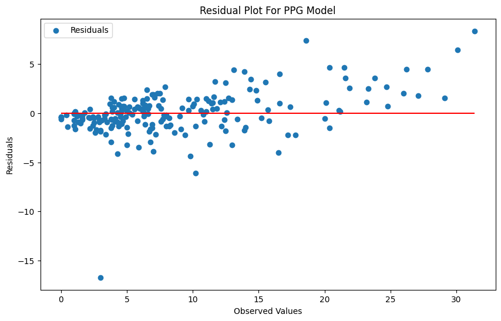

```python
r_squared = rf_ppg.score(X_test_ppg, y_test_ppg)
print("The R-Squared value of our PPG Model is", r_squared)

residuals_ppg = y_test_ppg - predictions_ppg

plt.figure(figsize=(10, 6))
plt.scatter(y_test_ppg, residuals_ppg, label='Residuals')
plt.hlines(y=0, xmin=y_test_ppg.min(), xmax=y_test_ppg.max(), colors='red')
plt.xlabel('Observed Values')
plt.ylabel('Residuals')
plt.title('Residual Plot For PPG Model')
plt.legend()
plt.show()
```

This value is fairly close to 1, further suggesting that we have a fairly strong model. The residual plot shows that residuals increase with points per game, indicating that our model still needs improvement.

We now want to know which features played a key role in the creation of our models, as after all, we want to know which features have an impact on PPG. To accomplish this, we analyze importances of each of the features we used.

```
    Feature  Importance
3        MP    0.845351
11      TOV    0.054691
6       2P%    0.015875
4       FG%    0.014723
7      eFG%    0.010105
8       FT%    0.009635
1         G    0.007678
0       Age    0.007665
5       3P%    0.007653
9       STL    0.007315
12       PF    0.005839
2        GS    0.005834
10      BLK    0.004390
15    Pos_F    0.001164
13  Playoff    0.000793
16    Pos_G    0.000755
14    Pos_C    0.000535
```

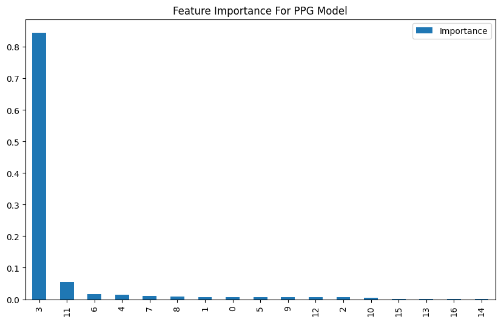

```python
# Get feature importances
importances = rf_ppg.feature_importances_

# Get feature names
names = X_train_ppg.columns

# Put the feature importances into a df so its pretty
feature_importances = pd.DataFrame({'Feature': names, 'Importance': importances})
feature_importances.sort_values(by='Importance', ascending=False, inplace=True)

# Display the feature importances
print(feature_importances)

plt.figure(figsize=(10, 6))
feature_importances['Importance'].plot(kind='bar')
plt.title('Feature Importance For PPG Model')
plt.legend()
plt.show()
```

We see that when our trees predict PPG, minutes played has an overwhelmingly large impact, as shown by its extremely high importance (0.845). Player turnovers have a minor impact on PPG, while the remainder of the features have an extremely minimal effect on our calculations for PPG. It is important to take away that minutes plays an extremely large role in calculating PPG.

Lastly, we look at an individual decision trees in our forest, so we can visualize what trees within our model look like. Note that we only show the first 4 levels of the tree to ensure it is visible.

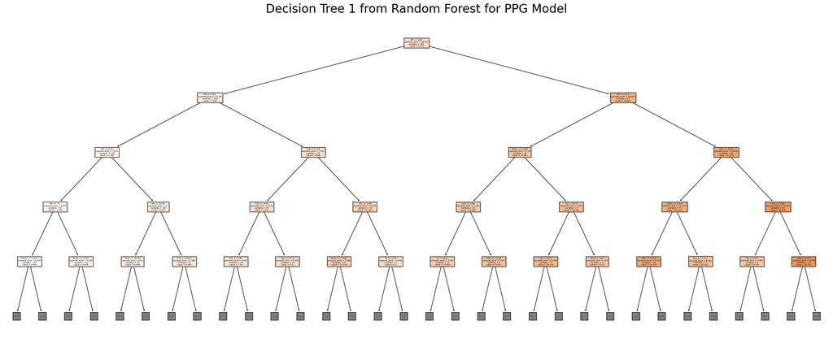

```python
# We choose to display the first tree
tree_index = 0

# Make sure plot is large enough
fig, ax = plt.subplots(figsize=(30, 12))  # Adjust figsize as needed to make it readable

# Plot the tree
plot_tree(rf_ppg.estimators_[tree_index], filled=True, ax=ax, feature_names=names, max_depth=4)
ax.set_title('Decision Tree 1 from Random Forest for PPG Model', fontsize=24)

plt.show()
```

### **RPG Model**

We first determine the root mean squared error (RMSE) of our model

```python
mse = mean_squared_error(y_test_rpg, predictions_rpg)
rmse = math.sqrt(mse)
print("The RMSE of our RPG Model is", rmse)
```

```
The RMSE of our RPG Model is 0.8962885017846502
```

Our RMSE of 0.896 is small relative to the number of rebounds an NBA player has in a game, indicating that our model has low error and performs well. Our RMSE is not super close to 0, giving belief that this model has avoided overfitting.

We next look at the R-Squared value of our model and plot the residuals to further analyze whether it is a good fit or not.

```
The R-Squared value of our RPG Model is 0.8221672982181999
```

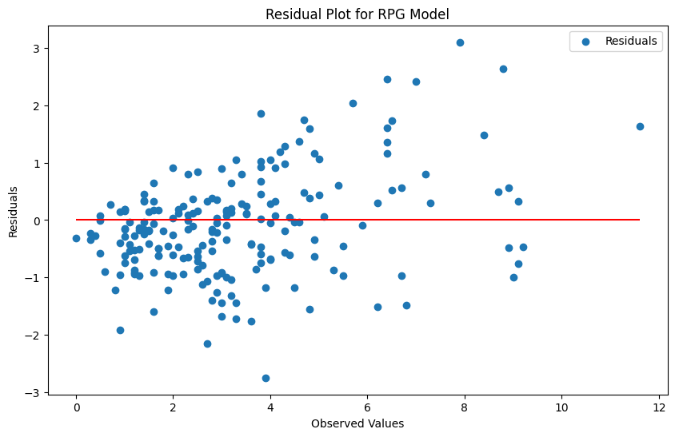

```python
r_squared = rf_rpg.score(X_test_rpg, y_test_rpg)
print("The R-Squared value of our RPG Model is", r_squared)

residuals_rpg = y_test_rpg - predictions_rpg

plt.figure(figsize=(10, 6))
plt.scatter(y_test_rpg, residuals_rpg, label='Residuals')
plt.hlines(y=0, xmin=y_test_rpg.min(), xmax=y_test_rpg.max(), colors='red')
plt.xlabel('Observed Values')
plt.ylabel('Residuals')
plt.title('Residual Plot for RPG Model')
plt.legend()
plt.show()
```

```
    Feature  Importance
2        GS    0.236751
3        MP    0.179631
12       PF    0.150808
4       FG%    0.119862
10      BLK    0.069777
14    Pos_C    0.062683
11      TOV    0.044637
5       3P%    0.021143
16    Pos_G    0.020266
6       2P%    0.020013
8       FT%    0.018235
9       STL    0.015201
1         G    0.011526
0       Age    0.011230
7      eFG%    0.009211
15    Pos_F    0.007048
13  Playoff    0.001979
```

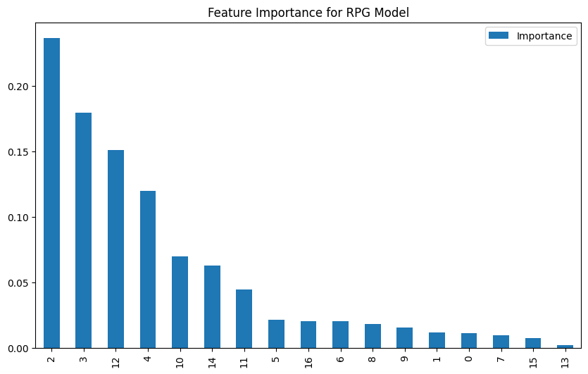

```python
# Get feature importances
importances = rf_rpg.feature_importances_

# Get feature names
names = X_train_rpg.columns

# Put the feature importances into a df so its pretty
feature_importances = pd.DataFrame({'Feature': names, 'Importance': importances})
feature_importances.sort_values(by='Importance', ascending=False, inplace=True)

# Display the feature importances
print(feature_importances)

plt.figure(figsize=(10, 6))
feature_importances['Importance'].plot(kind='bar')
plt.title('Feature Importance for RPG Model')
plt.legend()
plt.show()
```

Here, we see that games started, minutes played, fouls, and field goal percentage all play important roles in rebounds per game, with games started interestingly having the highest importance (0.237). Blocks, whether or not a player is a center, and turnovers also have minor impacts when predicting RPG. Our main takeaway can be that games started, minutes played, fouls, and field goal percentage play the largest roles in predicting RPG, and that there is no one feature "doing most of the work" in predicting RPG.

Lastly, we look at an individual decision trees in our forest, so we can visualize what trees within our model look like. Note that we only show the first 4 levels of the tree to ensure it is visible.

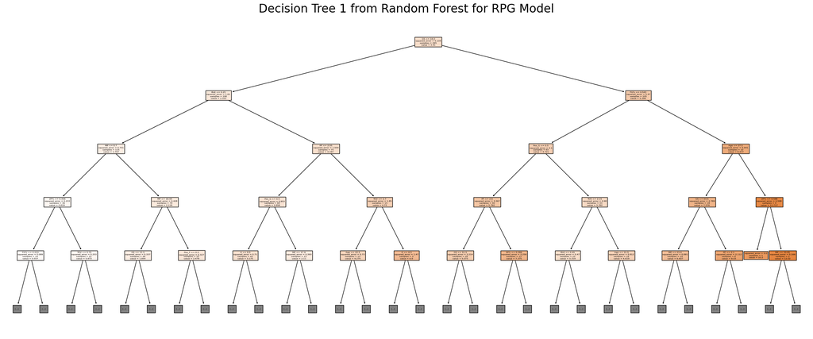

```python
# We choose to display the first tree
tree_index = 0

# Make sure plot is large enough
fig, ax = plt.subplots(figsize=(30, 12))  # Adjust figsize as needed to make it readable

# Plot the tree
plot_tree(rf_rpg.estimators_[tree_index], filled=True, ax=ax, feature_names=names, max_depth=4)
ax.set_title("Decision Tree 1 from Random Forest for RPG Model", fontsize=24)
plt.show()
```

### **APG Model**

We first determine the root mean squared error (RMSE) of our model

```python
mse = mean_squared_error(y_test_apg, predictions_apg)
rmse = math.sqrt(mse)
print("The RMSE of our APG Model is", rmse)
```

```
The RMSE of our APG Model is 0.8880284701097653
```

We next look at the R-Squared value of our model and plot the residuals to further analyze whether it is a good fit or not.

```
The R-Squared value of our APG Model is 0.7782006288724571
```

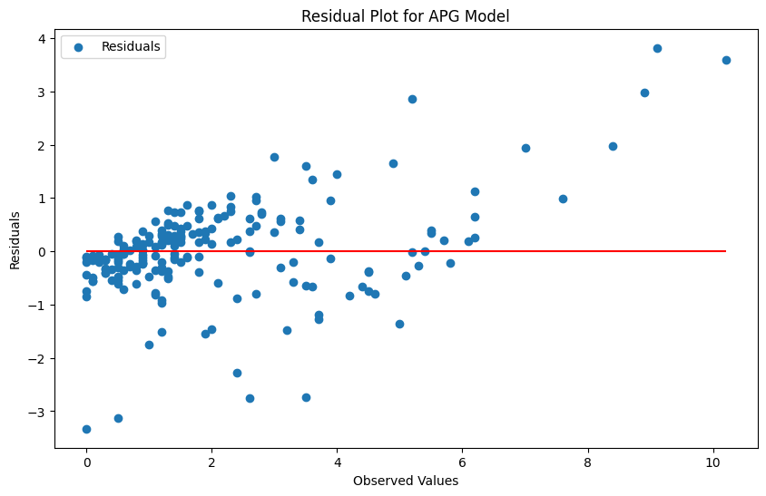

```python
r_squared = rf_apg.score(X_test_apg, y_test_apg)
print("The R-Squared value of our APG Model is", r_squared)

residuals_apg = y_test_apg - predictions_apg

plt.figure(figsize=(10, 6))
plt.scatter(y_test_apg, residuals_apg, label='Residuals')
plt.hlines(y=0, xmin=y_test_apg.min(), xmax=y_test_apg.max(), colors='red')
plt.xlabel('Observed Values')
plt.ylabel('Residuals')
plt.title('Residual Plot for APG Model')
plt.legend()
plt.show()
```

This value is slightly close to 1, suggesting that our model has a good (but not excellent) fit. This gives reason to believe that our model has room for improvement. We also see that residuals increase with assists per game, further indicating that improvements are needed in our model.

```
    Feature  Importance
11      TOV    0.669077
3        MP    0.083762
9       STL    0.046279
16    Pos_G    0.037086
5       3P%    0.026502
0       Age    0.022923
12       PF    0.020644
8       FT%    0.018050
1         G    0.013045
7      eFG%    0.013018
6       2P%    0.012591
2        GS    0.012264
4       FG%    0.010645
10      BLK    0.008884
14    Pos_C    0.001854
13  Playoff    0.001843
15    Pos_F    0.001533
```

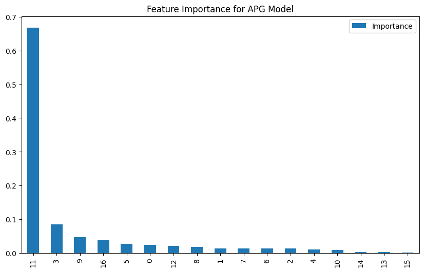

```python
# Get feature importances
importances = rf_apg.feature_importances_

# Get feature names
names = X_train_apg.columns

# Put the feature importances into a df so its pretty
feature_importances = pd.DataFrame({'Feature': names, 'Importance': importances})
feature_importances.sort_values(by='Importance', ascending=False, inplace=True)

# Display the feature importances
print(feature_importances)

plt.figure(figsize=(10, 6))
feature_importances['Importance'].plot(kind='bar')
plt.title('Feature Importance for APG Model')
plt.legend()
plt.show()
```

Here, we see that turnovers have, by a large margin, the most importance (0.669)in calculating assists per game. Minutes played, steals, whether or not a player is a guard, 3 point percentage, age, fouls, and free throw percentage all have minor impacts on predicting APG. Overall, it is most important to note how turnovers have an overwhelmingly large impact on calculating APG.

Lastly, we look at an individual decision trees in our forest, so we can visualize what trees within our model look like. Note that we only show the first 4 levels of the tree to ensure it is visible.

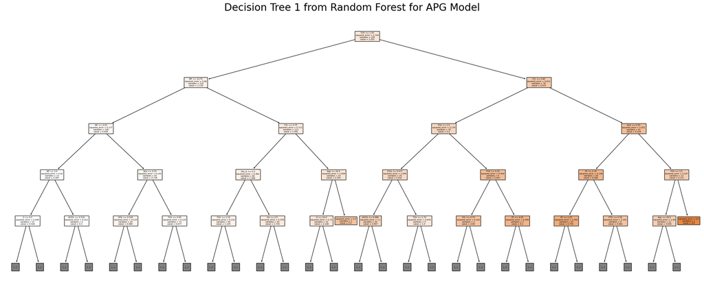

```python
# We choose to display the first tree
tree_index = 0

# Make sure plot is large enough
fig, ax = plt.subplots(figsize=(30, 12))  # Adjust figsize as needed to make it readable

# Plot the tree
plot_tree(rf_apg.estimators_[tree_index], filled=True, ax=ax, feature_names=names, max_depth=4)
ax.set_title("Decision Tree 1 from Random Forest for APG Model", fontsize=24)
plt.show()
```

## **Analysis of Models**

One possibility is that our models overfit our training data. We created random forest models in attempt to avoid overfitting (as decision trees are notorious for overfitting), but we did not create any depth limit. The lack of depth limits could have prompted overfitting, as models with no depth limit tend to face such issues.

We also could have simply picked an inadequate model. Linear regression models could have been used (with more tedious data encoding and deletion of some features). Unsupervised algorithms also could have possibly been used.

Lastly, there is also the simple chance that we did not have enough data to properly predict PPG, RPG, and APG. Some of the features we have did not seem like strong predictors for PPG, RPG, and APG in our data exploration, and the features that ended up playing a large role in our models do not seem like they would be enough to predict the major statistics alone. While the features we have would likely be enough to predict if someone had a high or low value for our statistics, there is a strong chance we lack the information necessary to determine specifically how high someone scored rather than if they scored a high value or low value.

# **4. Insights and Conclusions**

Our goal of this project was to gain a better understanding of NBA player's points per game, rebounds per game, and assists per game by analyzing 2022-23 Season data.

When studying points per game, we determined the following: Through our exploration, we discovered that age, position, and team quality played little role in determining PPG. Our ML model's feature importances however gave us better insight on what plays a role in predicting PPG. The highest scoring players are usually the ones with the most minutes played, turnovers also play a role along with field goal percentage, but not nearly as much as playing more minutes. This makes sense, as more time on the court will give players more opportunities to score and fewer turnovers could result in more scoring oppportunities.

Through our data exploration and ML model, we were able to gain a better understanding of what statistics play a role in predicting the three major player statistics (PPG, RPG, APG) in basketball. While we improved our understanding, our model showed room for improvements as well.